# SQL Window Functions: Stock Price Averages

Author

Aniss Sahraoui

Published

September 19, 2026

# 1 Overview

This assignment uses SQL **window functions** to calculate two averages of daily stock prices:

- **Year-to-date average:** the average closing price from the start of the year up to each day.
- **Six-day moving average:** the average of each day’s closing price and the five trading days before it.

Both are calculated separately for each stock. A window function is what makes this possible: it calculates a value for every row from a “window” of related rows, without collapsing the rows the way `GROUP BY` does.

# 2 The Data

The data is the daily closing price of three stocks, **Apple (AAPL)**, **Microsoft (MSFT)** and **Amazon (AMZN)**, from January 3, 2022 (the first trading day of 2022) to September 18, 2026. It was downloaded from Yahoo Finance and saved as `data/stock_prices.csv` in my GitHub repository, so the results do not change when new prices come in. The code below reads the file directly from GitHub. Prices are adjusted for stock splits, such as Amazon’s 20-for-1 split in 2022.

```r
prices <- read_csv(
  "https://raw.githubusercontent.com/AnissSahraoui/DATA607/main/Week3B/data/stock_prices.csv",
  show_col_types = FALSE
)

prices |>
  group_by(ticker) |>
  summarise(trading_days = n(), first_day = min(date), last_day = max(date),
            lowest_close = min(close), highest_close = max(close))
```

| ticker | trading_days | first_day | last_day | lowest_close | highest_close |
| --- | --- | --- | --- | --- | --- |
| AAPL | 1182 | 2022-01-03 | 2026-09-18 | 125.02 | 340.08 |
| AMZN | 1182 | 2022-01-03 | 2026-09-18 | 81.82 | 284.02 |
| MSFT | 1182 | 2022-01-03 | 2026-09-18 | 214.25 | 542.07 |

# 3 Loading the Data into SQL

The prices go into a SQLite table with one row per stock per day. The primary key `(ticker, date)` makes sure no day is loaded twice for the same stock.

```sql
-- 01_create_table.sql
-- One row per stock per trading day.

DROP TABLE IF EXISTS stock_prices;

CREATE TABLE stock_prices (
  date    TEXT NOT NULL,   -- YYYY-MM-DD
  ticker  TEXT NOT NULL,
  close   REAL NOT NULL,   -- closing price in US dollars
  PRIMARY KEY (ticker, date)
);
```

```r
# Run a .sql file one statement at a time
run_sql_file <- function(con, path) {
  statements <- readLines(path) |>
    str_remove("--.*$") |>
    paste(collapse = "\n") |>
    str_split_1(";") |>
    str_trim()
  walk(statements[statements != ""], \(s) dbExecute(con, s))
}

con <- dbConnect(SQLite(), ":memory:")
run_sql_file(con, "sql/01_create_table.sql")

dbAppendTable(con, "stock_prices", prices |> mutate(date = as.character(date)))
```

```
[1] 3546
```

```r
dbGetQuery(con, "SELECT ticker, COUNT(*) AS rows FROM stock_prices GROUP BY ticker")
```

| ticker | rows |
| --- | --- |
| AAPL | 1182 |
| AMZN | 1182 |
| MSFT | 1182 |

# 4 The Window Functions

This is the full query, saved as `sql/02_window_functions.sql`:

```sql
-- 02_window_functions.sql
-- Year-to-date average and six-day moving average of the closing price, for each stock.

SELECT
  date,
  ticker,
  close,

  -- Year-to-date average: every day from January 1 of the same year up to this day.
  -- PARTITION BY ticker and year makes the average restart each January for each stock.
  AVG(close) OVER (
    PARTITION BY ticker, strftime('%Y', date)
    ORDER BY date
    ROWS BETWEEN UNBOUNDED PRECEDING AND CURRENT ROW
  ) AS ytd_avg,

  -- Six-day moving average: this trading day and the five before it.
  -- The first five days of each stock have fewer than six days of history, so they are NULL.
  CASE
    WHEN COUNT(close) OVER six_days = 6 THEN AVG(close) OVER six_days
  END AS moving_avg_6d

FROM stock_prices
WINDOW six_days AS (
  PARTITION BY ticker
  ORDER BY date
  ROWS BETWEEN 5 PRECEDING AND CURRENT ROW
)
ORDER BY ticker, date;
```

How each part works:

| Part | What it does |
| --- | --- |
| `PARTITION BY ticker` | Calculates each stock separately |
| `strftime('%Y', date)` | Also splits by year, so the year-to-date average restarts every January |
| `ORDER BY date` | Puts each stock’s days in order |
| `ROWS BETWEEN UNBOUNDED PRECEDING AND CURRENT ROW` | Year-to-date: every day so far this year |
| `ROWS BETWEEN 5 PRECEDING AND CURRENT ROW` | Six-day: today and the five trading days before it |

Two details:

- The moving average counts **trading days**, not calendar days. Weekends and holidays have no price, so six trading days usually span eight calendar days.
- The first five days of each stock do not have six days of history yet. `COUNT(close) OVER six_days` counts the days in the window, and the moving average is left empty until there are six.

```r
query <- paste(readLines("sql/02_window_functions.sql"), collapse = "\n")

results <- dbGetQuery(con, query) |>
  as_tibble() |>
  mutate(date = as.Date(date))

dbDisconnect(con)

results |> filter(ticker == "AAPL") |> head(8)
```

| date | ticker | close | ytd_avg | moving_avg_6d |
| --- | --- | --- | --- | --- |
| 2022-01-03 | AAPL | 182.01 | 182.0100 | NA |
| 2022-01-04 | AAPL | 179.70 | 180.8550 | NA |
| 2022-01-05 | AAPL | 174.92 | 178.8767 | NA |
| 2022-01-06 | AAPL | 172.00 | 177.1575 | NA |
| 2022-01-07 | AAPL | 172.17 | 176.1600 | NA |
| 2022-01-10 | AAPL | 172.19 | 175.4983 | 175.4983 |
| 2022-01-11 | AAPL | 175.08 | 175.4386 | 174.3433 |
| 2022-01-12 | AAPL | 175.53 | 175.4500 | 173.6483 |

The first row’s year-to-date average equals its closing price, because it is the only day so far. The moving average starts on the sixth row.

The year-to-date average restarts on the first trading day of each year:

```r
results |>
  filter(ticker == "AAPL", date >= "2022-12-28", date <= "2023-01-05")
```

| date | ticker | close | ytd_avg | moving_avg_6d |
| --- | --- | --- | --- | --- |
| 2022-12-28 | AAPL | 126.04 | 155.0364 | 131.3183 |
| 2022-12-29 | AAPL | 129.61 | 154.9347 | 130.8700 |
| 2022-12-30 | AAPL | 129.93 | 154.8351 | 129.9500 |
| 2023-01-03 | AAPL | 125.07 | 125.0700 | 128.7567 |
| 2023-01-04 | AAPL | 126.36 | 125.7150 | 127.8400 |
| 2023-01-05 | AAPL | 125.02 | 125.4833 | 127.0050 |

On January 3, 2023, the year-to-date average drops back to that day’s price. The moving average does not restart, because the five days before it are still the most recent trading days.

# 5 Checking the Results

To make sure the SQL is correct, I calculate the same averages a second way, with `dplyr` in R, and compare them.

```r
check <- prices |>
  group_by(ticker, year = year(date)) |>
  arrange(date, .by_group = TRUE) |>
  mutate(ytd_check = cummean(close)) |>
  group_by(ticker) |>
  mutate(ma_check = (close + lag(close, 1) + lag(close, 2) +
                     lag(close, 3) + lag(close, 4) + lag(close, 5)) / 6) |>
  ungroup()

comparison <- results |>
  inner_join(check, by = c("ticker", "date"))

tibble(
  rows_compared             = nrow(comparison),
  largest_ytd_difference    = max(abs(comparison$ytd_avg - comparison$ytd_check)),
  largest_6day_difference   = max(abs(comparison$moving_avg_6d - comparison$ma_check), na.rm = TRUE),
  empty_6day_values_match   = all(is.na(comparison$moving_avg_6d) == is.na(comparison$ma_check))
)
```

| rows_compared | largest_ytd_difference | largest_6day_difference | empty_6day_values_match |
| --- | --- | --- | --- |
| 3546 | 0 | 0 | TRUE |

The two methods agree on all 3,546 rows: the largest difference is 0, and the empty moving-average values are in the same places.

# 6 Results

## 6.1 Latest values

```r
results |>
  group_by(ticker) |>
  slice_max(date) |>
  ungroup() |>
  mutate(across(c(close, ytd_avg, moving_avg_6d), ~ round(.x, 2)),
         `close vs YTD avg` = scales::percent((close - ytd_avg) / ytd_avg, 0.1))
```

| date | ticker | close | ytd_avg | moving_avg_6d | close vs YTD avg |
| --- | --- | --- | --- | --- | --- |
| 2026-09-18 | AAPL | 336.13 | 287.56 | 333.70 | 16.9% |
| 2026-09-18 | AMZN | 253.71 | 241.62 | 251.60 | 5.0% |
| 2026-09-18 | MSFT | 493.78 | 425.49 | 496.66 | 16.0% |

## 6.2 2026 so far

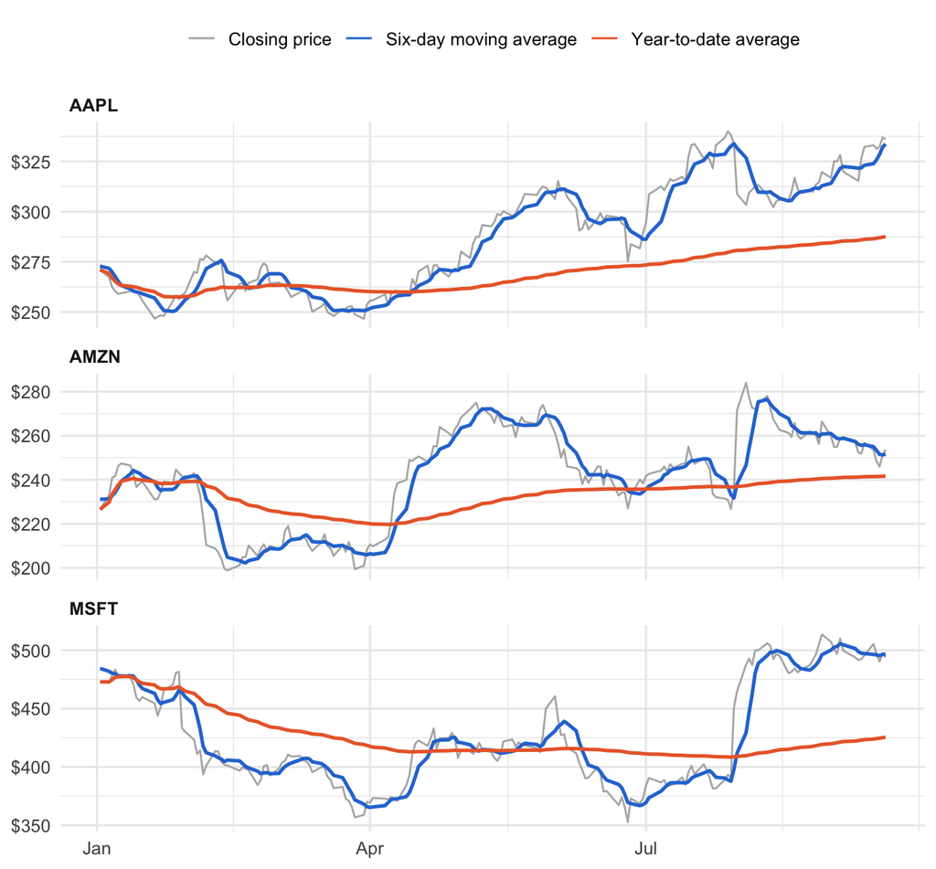

Figure 1: Daily closing price in 2026 with the six-day moving average and the year-to-date average.

```r
results |>
  filter(date >= "2026-01-01") |>
  select(date, ticker, `Closing price` = close, `Six-day moving average` = moving_avg_6d,
         `Year-to-date average` = ytd_avg) |>
  pivot_longer(-c(date, ticker), names_to = "series", values_to = "price") |>
  mutate(series = factor(series, levels = c("Closing price", "Six-day moving average",
                                            "Year-to-date average"))) |>
  ggplot(aes(x = date, y = price, color = series, linewidth = series)) +
  geom_line() +
  facet_wrap(~ ticker, ncol = 1, scales = "free_y") +
  scale_color_manual(values = c("Closing price" = "grey70",
                                "Six-day moving average" = "#2a78d6",
                                "Year-to-date average" = "#eb6834"), name = NULL) +
  scale_linewidth_manual(values = c(0.5, 0.9, 0.9), guide = "none") +
  scale_y_continuous(labels = scales::dollar) +
  labs(x = NULL, y = NULL) +
  theme_minimal(base_size = 12) +
  theme(legend.position = "top", strip.text = element_text(face = "bold", hjust = 0))
```

The chart shows what each average is good for:

- The **six-day moving average** follows the price closely but smooths out day-to-day noise.
- The **year-to-date average** moves slowly and becomes more stable as the year goes on, because each new day is a smaller share of the total. A price above the year-to-date average means the stock is trading higher than it has on average this year.

# 7 Conclusion

- One SQL query with two window functions calculates both averages for all three stocks and all years at once, without any loops.
- `PARTITION BY` keeps the stocks separate, and adding the year to the partition makes the year-to-date average restart each January.
- The `ROWS BETWEEN` frame controls how many days go into each average.
- The results match the same calculation done with `dplyr` in R.

The same query would work for any number of stocks, or for any other daily time series, by changing only the table.